# Classwork 04: Wine Quality Prediction (Regression) with K-Fold Cross-Validation and Hyperparameter Optimization

## **Dataset Overview:**

- **Name:** Wine Quality Dataset (choose the Red Wine data) from UCI Machine Learning Repository
- **Link:** https://archive.ics.uci.edu/ml/datasets/Wine+Quality
- **Description:** Predict wine quality scores based on physicochemical tests.
- **Target Variable:** `quality` (score between 0 and 10)
- **Features (11):** Fixed acidity, volatile acidity, citric acid, residual sugar, chlorides, free sulfur dioxide, total sulfur dioxide, density, pH, sulphates, and alcohol.

## **Objective**

You will train regression models using the **Wine Quality Dataset**, evaluate performance using **5-Fold Cross-Validation**, and further **optimize models using GridSearchCV and RandomizedSearchCV**.

### **Problem Statement:**

- **Predict the wine quality score** based on chemical properties.
- Evaluate results using **RMSE**.
- Optimize hyperparameters using **Grid Search and Random Search**.

## **Tasks:**

1. **Read the instructions carefully and use exactly the given variable names. Do not change the ready-given code!**
2. **Data Preprocessing:**
   - Load the dataset, handle missing values, and scale features.
3. **Model Training (5-Fold CV):**
   - Train Linear Regression, Decision Tree Regressor, and Random Forest Regressor models.
   - Report RMSE for cross-validation.
4. **Model Optimization**
   - Use **GridSearchCV** to tune hyperparameters for **Decision Tree Regressor**.
     - Use the following hyperparameters and values: max_depth: [5, 10, 15] and min_samples_split: [2, 5, 10]}
   - Use **RandomizedSearchCV** to tune hyperparameters for **Random Forest Regressor**.
     - Use the following hyperparameters and values: n_estimators: [1, 200], max_depth: [5, 20], min_samples_split: [2, 10]
   - Report the best hyperparameters and RMSE scores.
5. **Final Model Evaluation**
   - Select the best-performing model based on RMSE.
   - Evaluate and report **RMSE on the test set** for the best model.
6. **Confidence Interval**
   - Compute 95% confidence interval for RMSE.

## Load libraries and data and check how the data looks like.

```python
import pandas as pd
import numpy as np
from sklearn.model_selection import train_test_split, cross_val_score, GridSearchCV, RandomizedSearchCV
from sklearn.preprocessing import StandardScaler
from sklearn.impute import SimpleImputer
from sklearn.linear_model import LinearRegression
from sklearn.tree import DecisionTreeRegressor
from sklearn.ensemble import RandomForestRegressor
from sklearn.metrics import mean_squared_error
import matplotlib.pyplot as plt

# Load dataset from "https://archive.ics.uci.edu/ml/machine-learning-databases/wine-quality/winequality-red.csv"

link = "https://archive.ics.uci.edu/ml/machine-learning-databases/wine-quality/winequality-red.csv"
data = pd.read_csv(link, sep = ";")

# Check, how the data look like (as instructed e.g. in earlier assignments)

data.info()
```

```
<class 'pandas.core.frame.DataFrame'>
RangeIndex: 1599 entries, 0 to 1598
Data columns (total 12 columns):
 #   Column                Non-Null Count  Dtype
---  ------                --------------  -----
 0   fixed acidity         1599 non-null   float64
 1   volatile acidity      1599 non-null   float64
 2   citric acid           1599 non-null   float64
 3   residual sugar        1599 non-null   float64
 4   chlorides             1599 non-null   float64
 5   free sulfur dioxide   1599 non-null   float64
 6   total sulfur dioxide  1599 non-null   float64
 7   density               1599 non-null   float64
 8   pH                    1599 non-null   float64
 9   sulphates             1599 non-null   float64
 10  alcohol               1599 non-null   float64
 11  quality               1599 non-null   int64
dtypes: float64(11), int64(1)
memory usage: 150.0 KB
```

```python
data.describe()
```

|  | fixed acidity | volatile acidity | citric acid | residual sugar | chlorides | free sulfur dioxide | total sulfur dioxide | density | pH | sulphates | alcohol | quality |
| --- | --- | --- | --- | --- | --- | --- | --- | --- | --- | --- | --- | --- |
| count | 1599.000000 | 1599.000000 | 1599.000000 | 1599.000000 | 1599.000000 | 1599.000000 | 1599.000000 | 1599.000000 | 1599.000000 | 1599.000000 | 1599.000000 | 1599.000000 |
| mean | 8.319637 | 0.527821 | 0.270976 | 2.538806 | 0.087467 | 15.874922 | 46.467792 | 0.996747 | 3.311113 | 0.658149 | 10.422983 | 5.636023 |
| std | 1.741096 | 0.179060 | 0.194801 | 1.409928 | 0.047065 | 10.460157 | 32.895324 | 0.001887 | 0.154386 | 0.169507 | 1.065668 | 0.807569 |
| min | 4.600000 | 0.120000 | 0.000000 | 0.900000 | 0.012000 | 1.000000 | 6.000000 | 0.990070 | 2.740000 | 0.330000 | 8.400000 | 3.000000 |
| 25% | 7.100000 | 0.390000 | 0.090000 | 1.900000 | 0.070000 | 7.000000 | 22.000000 | 0.995600 | 3.210000 | 0.550000 | 9.500000 | 5.000000 |
| 50% | 7.900000 | 0.520000 | 0.260000 | 2.200000 | 0.079000 | 14.000000 | 38.000000 | 0.996750 | 3.310000 | 0.620000 | 10.200000 | 6.000000 |
| 75% | 9.200000 | 0.640000 | 0.420000 | 2.600000 | 0.090000 | 21.000000 | 62.000000 | 0.997835 | 3.400000 | 0.730000 | 11.100000 | 6.000000 |
| max | 15.900000 | 1.580000 | 1.000000 | 15.500000 | 0.611000 | 72.000000 | 289.000000 | 1.003690 | 4.010000 | 2.000000 | 14.900000 | 8.000000 |

```python
data.isnull().sum()
```

```
fixed acidity           0
volatile acidity        0
citric acid             0
residual sugar          0
chlorides               0
free sulfur dioxide     0
total sulfur dioxide    0
density                 0
pH                      0
sulphates               0
alcohol                 0
quality                 0
dtype: int64
```

```python
# Noticed the minimum value for column citric acidity is 0 so I want to see how many values are 0 in the column and
# research wether that is normal
# we see that 132 rows have value 0 on that column BUT after researching it is normal for wines to have 0 value on citric acid so
# we choose not to do any changes on that

(data["citric acid"] == 0).sum()
```

```
132
```

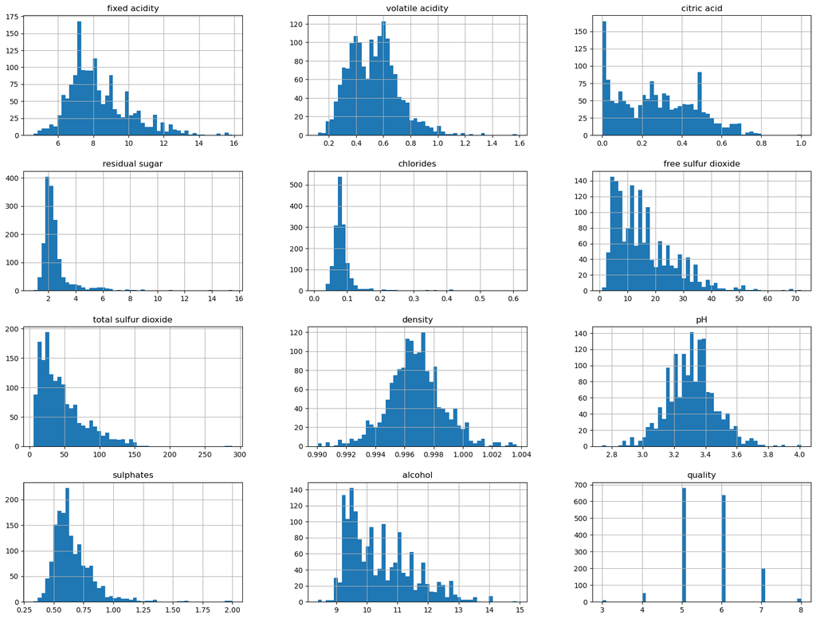

```python
# Quick inspection of the frequency of values for each attribute
# We notice there is a lot of right skewed attributes

data.hist(bins = 50, figsize = (20,15))
plt.show()
```

```python
# Checking the skewness of each attribute for extra info and understanding of the dataset
# As suspected from the graphs too, some attributes are heavily right skewed so we will have to do something about that
# residual sugar, chlorides, sulphates are the main ones

data.skew()
```

```
fixed acidity           0.982751
volatile acidity        0.671593
citric acid             0.318337
residual sugar          4.540655
chlorides               5.680347
free sulfur dioxide     1.250567
total sulfur dioxide    1.515531
density                 0.071288
pH                      0.193683
sulphates               2.428672
alcohol                 0.860829
quality                 0.217802
dtype: float64
```

## Use X as features and y as target ("quality" feature shall be in y and rest of the features in X).

```python
# Split features and target.
# Check, that it worked.

X = data.drop("quality", axis = 1)
y = data["quality"]
X.shape
y.shape
```

```
(1599,)
```

```python
# Use train_test_split with 80-20 split and random_state=42.
# Make sure your data is in X_train, X_test, y_train, y_test

X_train, X_test, y_train, y_test = train_test_split(
    X, y,
    test_size = 0.2,
    random_state = 42
)
```

```python
X_train.shape
```

```
(1279, 11)
```

```python
X_test.shape
```

```
(320, 11)
```

```python
y_train.shape
```

```
(1279,)
```

```python
y_test.shape
```

```
(320,)
```

## Impute missing values with "mean". Use SimpleImputer. Fit and transform the training data.

## Then transform the test data (**do not fit on test data, only transform**).

```python
# Handle missing values

imputer = SimpleImputer(strategy = "mean")

X_train = imputer.fit_transform(X_train)

X_test = imputer.transform(X_test)
```

## Scale data using StandardScaler(). Fit and transform the training data.

## Then transform the test data (**do not fit on test data, only transform**).

```python
# Scale features

scaler = StandardScaler()

X_train = scaler.fit_transform(X_train)

X_test = scaler.transform(X_test)
```

## Use the LinearRegression() model.

### Use 5-fold cross validation.

```python
# Create a linear regression model, whose name is lin_reg.
# Do not fit, since the fitting is done by the cross_val_score-function

lin_reg = LinearRegression()

# Evaluate the model
lin_scores = cross_val_score(lin_reg, X_train, y_train, scoring = 'neg_mean_squared_error', cv = 5)
lin_rmse_scores = np.sqrt(-lin_scores)
print(f"Linear Regression RMSE (5-Fold CV): {lin_rmse_scores.mean():.4f}")
```

```
Linear Regression RMSE (5-Fold CV): 0.6621
```

## Fit the linear regression model (on the X_train, y_train) and predict (on the X_test)

```python
# Cross-validation does NOT leave you with a trained model you can use, therefore, you need to fit now.

# Fitting

lin_reg.fit(X_train, y_train)

# Predicting on the test set (X_test)

lin_y_pred = lin_reg.predict(X_test)


# Check the RMSE score
lin_test_rmse = np.sqrt(mean_squared_error(y_test, lin_y_pred))
print(f"Linear Regression RMSE (Test Set): {lin_test_rmse:.4f}")
print("-"*50)
```

```
Linear Regression RMSE (Test Set): 0.6245
--------------------------------------------------
```

## Replicate the process for DecisionTreeRegressor()

```python
# Train and Evaluate Decision Tree Regressor
# Notice: do not split, impute or scale the data any more.
# Create a decision tree regression model, whose name is tree_reg

tree_reg = DecisionTreeRegressor(random_state=42)


# Evaluate the model (use tree_scores and tree_rmse_scores)

tree_scores = cross_val_score(tree_reg, X_train, y_train, scoring='neg_mean_squared_error', cv = 5)
tree_rmse_scores = np.sqrt(-tree_scores)
print(f"Decision Tree Regression RMSE (5-Fold CV): {tree_rmse_scores.mean():.4f}")

# Fit
tree_reg.fit(X_train, y_train)

# Predict

tree_y_pred = tree_reg.predict(X_test)

# Check the RMSE score

tree_test_rmse = np.sqrt(mean_squared_error(y_test, tree_y_pred))
print(f"Decision Tree Regression RMSE (Test Set): {tree_test_rmse:.4f}")
print("-"*50)
```

```
Decision Tree Regression RMSE (5-Fold CV): 0.8194
Decision Tree Regression RMSE (Test Set): 0.7826
--------------------------------------------------
```

## Let's do a grid search for Decision Tree

```python
# Grid Search for Decision Tree (do not change the code)

# Use GridSearchCV to tune hyperparameters for Decision Tree Regressor.
# Use the following hyperparameters and values: max_depth: [5, 10, 15] and min_samples_split: [2, 5, 10]}

param_grid = {
    "max_depth": [5, 10, 15],
    "min_samples_split": [2, 5, 10]
}

grid_search = GridSearchCV(
    estimator = DecisionTreeRegressor(random_state=42),
    param_grid = param_grid,
    scoring = "neg_mean_squared_error",
    cv = 5
)

grid_search.fit(X_train, y_train)

print("Best Decision Tree Parameters:", grid_search.best_params_)
print(f"Best Decision Tree RMSE (CV): {np.sqrt(-grid_search.best_score_):.4f}")
```

```
Best Decision Tree Parameters: {'max_depth': 5, 'min_samples_split': 2}
Best Decision Tree RMSE (CV): 0.6946
```

## Let's do a randomized search for Random Forest Regressor

```python
# Randomized Search for Random Forest (do not change the code)
from scipy.stats import randint
from sklearn.ensemble import RandomForestRegressor
from sklearn.model_selection import RandomizedSearchCV

# Use RandomizedSearchCV to tune hyperparameters for Random Forest Regressor.
# Use the following hyperparameters and values: n_estimators: [1, 200], max_depth: [5, 20], min_samples_split: [2, 10]

# Define the model, use random_state=

rf_reg = RandomForestRegressor(random_state=42)

# Define the parameter grid using randint

param_distributions = {
    "n_estimators": randint(1, 200),
    "max_depth": randint(5, 20),
    "min_samples_split": randint(2, 10)
}

# Perform Randomized Search

random_search = RandomizedSearchCV(
    estimator = rf_reg,
    param_distributions = param_distributions,
    n_iter = 50,
    scoring = "neg_mean_squared_error",
    cv = 5,
    random_state = 42,
    n_jobs = -1
)

# Fit

random_search.fit(X_train, y_train)

# Print best parameters and RMSE. Do not change.
print("Best Random Forest Parameters:", random_search.best_params_)
print(f"Best Random Forest RMSE (CV): {np.sqrt(-random_search.best_score_):.4f}")
```

```
Best Random Forest Parameters: {'max_depth': 14, 'min_samples_split': 2, 'n_estimators': 188}
Best Random Forest RMSE (CV): 0.6090
```

## Let's find out the best model and it's performance on the test set.

```python
best_model = random_search.best_estimator_
print("Best model is: ", best_model)

y_test_pred = best_model.predict(X_test)

test_rmse = np.sqrt(mean_squared_error(y_test, y_test_pred))
print(f"Final Model RMSE on Test Set: {test_rmse:.4f}")
```

```
Best model is:  RandomForestRegressor(max_depth=14, n_estimators=188, random_state=42)
Final Model RMSE on Test Set: 0.5554
```

## Check the confidence interval.

```python
from scipy import stats

# Set the confidence level (95%)

confidence = 0.95

# Calculating the squared errors (an array) between the final predictions and the true values

squared_errors = (y_test_pred - y_test) ** 2

# Computing the confidence interval for the mean squared errors using the t-distribution

np.sqrt(stats.t.interval(confidence, len(squared_errors) - 1,
                         loc = squared_errors.mean(),
                         scale = stats.sem(squared_errors)))
```

```
array([0.50102881, 0.60488474])
```

### Answer the following questions.

1. Explain briefly, what do the results mean? And what do they tell about wine quality?
2. What is the best model?
3. What is the RMSE score of the best model?
4. Explain, what does the confidence interval mean.
5. What is the confidence interval of the best model?
6. Is the score of the best model good or bad? Why?

Double click this cell and write down your answers.

1. . The results show how accurately the models we trained, can predict wine quality based on the physicochemical properties. The RMSE measures the average prediction error between the predicted and the actual wine quality values. For example, if the mean wine quality is 5, our model will predict 0.55 off that 5 consistently, as in from 4.45 to 5.55. Considering the wine values range from 3-8 then 0.6 is an acceptable result for a model.
2. . The best performing model is the Random Forest Regressor with the lowest RMSE score on both the cross-validation and the test set data.
3. . The RMSE score on the test set is 0.5554 for Random Forest Regressor. It means that on average the model predicts about 0.56 quality points awaya from the true value.
4. . It means that if we provided the model with a different sample or repeated the the whole procedure many times, the confidence interval will be different each time. The confidence tells us the true average error of the model. If we repeated the process changing for example how we split the data for 100 times, about 95 times the interval would contain the true average RMSE.
5. . The confidence interval of the Random Forest Regressor is 0.50102881 - 0.60488474.
6. . The score of 0.5554 is acceptable and good considering of course the min and max values of the quality attribute ranges from 3-8. Additonally, the prediction error being under 1 quality point is a good indicator. Of course the smaller the range of the value of the attribute the worse our result will be considered to be, while the larger the better it will be considered. It is important to consider that the quality of the wine is of course initially somewhat subjective, so a perfect prediction is highly unlikely.